# Examen parcial - Primavera 2021

Por último, se analiza la interacción entre la duración y la variabilidad de la temprada de crecimiento. La hipótesis sugiere que cuando ambas son muy largas o muy cortas relativas al promedio, la diversidad linguística se reduce. En este caso, de acuerdo con nuestro modelo, la hipótesis sí puede confirmarse. De acuerdo con la distribución posterior de los parámetros, el intervalo de confianza con 90% de certeza se encuentra entre -0.1261 y -0.0097. Estos intervalos confirman la relación negativa entre la interacción de `mean.growing.season` y `sd.growing.season` en la diversidad linguística.

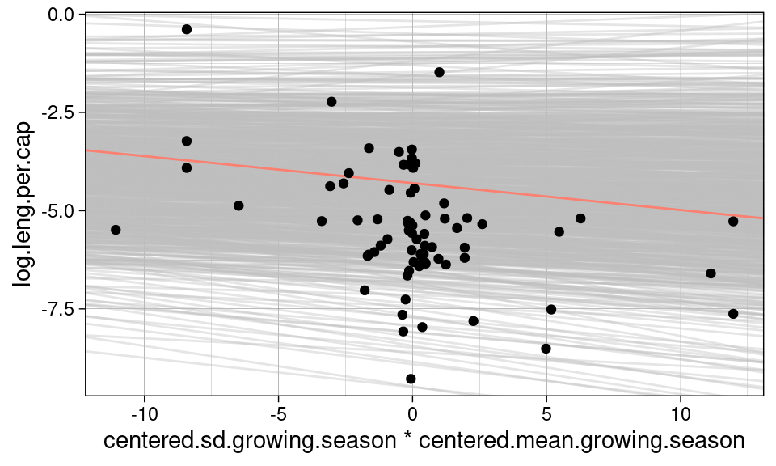

```r
ggplot(data = data_centered, aes(x = centered.sd.growing.season*centered.mean.growing.season, y = log.leng.per.cap))  +
    geom_abline(data = as_tibble(model_centered_4) %>% sample_frac(.2),
                aes(slope = centered.sd.growing.season*centered.mean.growing.season, intercept = `(Intercept)`),
                color = 'grey', alpha = .4) +
    geom_abline(slope = coef(model_centered_4)[6], intercept = coef(model_centered_4)[1], color = 'salmon') +
    geom_point()
```

[figure not shown]

```r
posterior_vs_prior(model_centered_4,pars= c("centered.mean.growing.season:centered.sd.growing.season"))
```

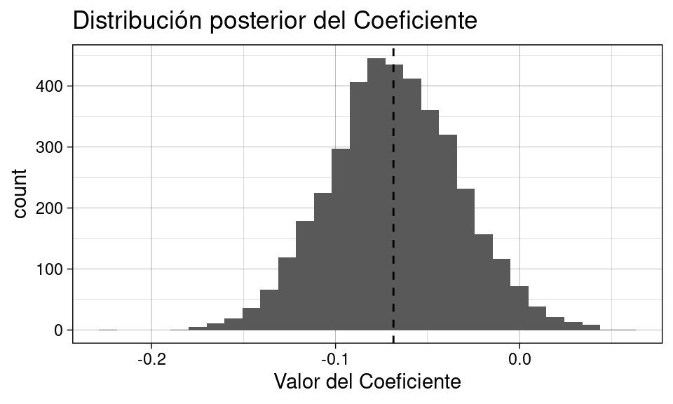

```r
as_tibble(model_centered_4)%>%
    ggplot(aes(x = `centered.mean.growing.season:centered.sd.growing.season`)) +
        geom_histogram() +
        geom_vline(xintercept = coef(model_centered_4)[6], lty = 2) +
        xlab("Valor del Coeficiente")+
        ggtitle("Distribución posterior del Coeficiente")
```

```r
posterior_interval(model_centered_4,pars= c("centered.mean.growing.season:centered.sd.growing.season"))
```

```
##                                                                 5%          95%
## centered.mean.growing.season:centered.sd.growing.season -0.1261484 -0.009790655
```